# STAT5003: Final Report

**Click to see hyperparameter tuning**

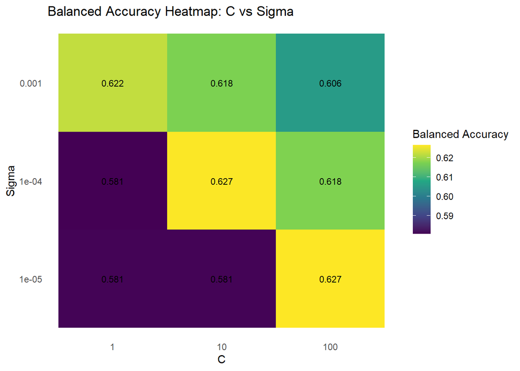

```r
set.seed(5003)
# Radial Model
svm_radial <- svm_rbf(cost = tune(), rbf_sigma = tune()) %>%
  set_engine("kernlab", maxiter = 6000, tol = 0.01) %>% # Can also add tol = 0.01 if still not converging.
  set_mode("classification")

radial_grid <- crossing(cost = 10^c(0,1,2),
                        rbf_sigma = c(0.00001,0.0001, 0.001)) # Default value should be 1/number of features (which is around 150).

cell_folds <- vfold_cv(crash.train.subset, v = 5, strata = `Degree of crash - detailed`) # Training on subset in the hopes that it'll actually give me something

# svm_radial
# radial_grid

# Making the Workflow
radial_wf <- workflow() %>%
  add_recipe(crash_recipe) %>%
  add_model(svm_radial)

# Tuning the model
radial_res <- radial_wf %>%
  tune_grid(
    resamples = cell_folds,
    grid = radial_grid,
    metrics = metric_set(f_meas, bal_accuracy),
    control = control_grid(
      verbose = FALSE
    )
  )

# Visualisation
results <- radial_res %>% collect_metrics()
# Filter for metric of interest
results_filtered <- results %>%
  filter(.metric == "bal_accuracy")

# Create heatmap
ggplot(results_filtered, aes(x = factor(cost), y = factor(round(rbf_sigma,6)), fill = mean)) +
  geom_tile() +
  geom_text(aes(label = round(mean, 3)), size = 3, color = "black") +
  scale_fill_viridis_c(option = "viridis") +  # or "plasma", "magma"
  labs(
    title = "Balanced Accuracy Heatmap: C vs Sigma",
    x = "C",
    y = "Sigma",
    fill = "Balanced Accuracy"
  ) +
  theme_minimal() +
  theme(
    panel.grid = element_blank(),
    axis.text.x = element_text(angle = 0, hjust = 0.5)
  )
```

The same process is repeated from the polynomial SVM: The top two models are trained with the full training set and the better one is used.

```r
relevant.cm <- result.list.rad[[1]]$confusion_matrix
p_cm_radial_svm <- relevant.cm$table %>% as.data.frame %>%
  ggplot(aes(x = Reference, y = Prediction, fill = Freq)) +
    geom_tile() +
    geom_text(aes(label = Freq), color = "white", size = 4) +
    scale_fill_gradient(low = "lightgrey", high = "darkblue") +
    labs(title = "Radial SVM - Confusion Matrix",
         x = "Actual Severity",
         y = "Predicted Severity") +
    theme_minimal() +
    theme(axis.text.x = element_text(angle = 30, hjust = 1))

# print(p_cm_radial_svm)

rel.cm <- result.list.rad[[1]]$confusion_matrix
f1 <- rel.cm$byClass[,"F1"] %>% mean(na.rm=TRUE)
bal_acc <- rel.cm$byClass[,"Balanced Accuracy"] %>% mean(na.rm=TRUE)
# cat("F1 score:",f1, "\n")
# cat("Balanced accuracy:",bal_acc)
results_df$Radial_SVM <- c("C: 10, Sigma: 0.001", round(f1,3), round(bal_acc, 3))
```

The radial model appears to have limited change over the polynomial kernel (F1 = 0.371; Bal. acc = 63.5%). The confusion matrices are plotted below to visualise the performance of the models on the test dataset. The overall patterns are consistent across the models: Groups of confusion between contextually similar crashes (i.e., no-casualty vs minor injury, moderate vs severe injury), and poor performance on the Fatal class.

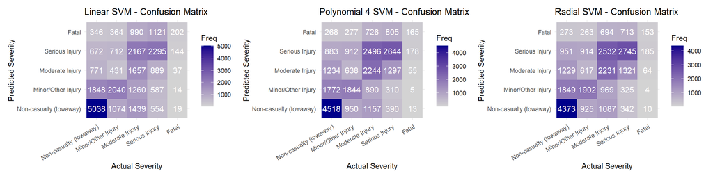

```r
p_cm_svm_lin + p_cm_svm_poly_4 + p_cm_radial_svm
```

## KNN

Our next model is a k-Nearest Neighbours model. The hyperparameter to tune here is k, the number of neighbours. Smaller values will increase the bias while increasing the variance, while larger values will do the opposite. The pre-processing is similar to the SVM models, but with more of a focus on reducing dimensionality, as KNN models perform poorly in high dimensions due to the curse of dimensionality (i.e., distances between data points in the high-dimensional space become large). The workflow is included in the following code, with comments for elaboration.

```r
# Selecting specific features for knn, as it struggles in high dimensions.
selected_features <- c(
  # Temporal after cyclical encoding
  "month_sin",
  "day_sin",
  "hour_sin",

  # High-impact categorical
  "Urbanisation",
  "Weather",
  "Natural lighting",
  "Street lighting",
  "Road surface",
  "Surface condition",
  "School zone active",

  # Speed and enforcement
  "Speed limit",
  "nearest_fixed_km",
  "nearest_redlight_km",

  # Impact characteristics
  "First impact type",
  "DCA - description",
  "Key TU type",
  "Other TU type",

  # Target
  "Degree of crash - detailed"
)

knn_data <- crash_data_SVC %>%
  dplyr::select(dplyr::all_of(selected_features))

binary_categoricals <- c(
  "School zone location", "School zone active",
  "Street lighting", "Natural lighting",
  "Signals operation", "Other traffic control"
)

for (col in binary_categoricals) {
  if (col %in% names(knn_data)) {
    knn_data[[col]] <- as.factor(knn_data[[col]])
  }
}

knn_split <- initial_split(knn_data, prop = 0.65, strata = `Degree of crash - detailed`)
knn.train <- training(knn_split) #
knn.test  <- testing(knn_split) #

knn_recipe <- recipe(`Degree of crash - detailed` ~ ., data = knn.train) %>%
  # Reduce high-cardinality categoricals
  step_other(all_nominal_predictors(), threshold = 0.01) %>%

  # Handle missing values for numeric predictors (impute with median)
  step_impute_median(all_numeric_predictors()) %>% # All remaining missing data is MAR or MCAR.

  # Handle missing values for categorical predictors (impute with mode)
  step_impute_mode(all_nominal_predictors()) %>%

  # Handle values that appear in CV test folds but not training folds
  step_novel(all_nominal_predictors(), new_level = "unseen") %>%

  # Create dummy variables for all categorical predictors, since SVM requires numeric inputs
  step_dummy(all_nominal_predictors(), one_hot = FALSE) %>% # Dummy coding instead of one-hot, more efficient for SVM

  # Remove zero-variance predictors (constant columns)
  step_zv(all_predictors()) %>% # Removes all columns that only have a single value (e.g., 0), since they cannot help the model

  # Feature Selection: Removing highly correlated features - done after creating dummy variables.
  step_corr(all_numeric_predictors(), threshold = 0.95) %>%

  step_zv(all_predictors()) %>% # Apparently step_corr can create zero-variance features, so this removes them?

  # Because we have severely imbalanced classes
  themis::step_downsample(`Degree of crash - detailed`, under_ratio = 1.5, seed = 5003, skip = TRUE) %>% # Can change skip = FALSE once hyperparameter tuning is complete to create a balanced model.

  step_zv(all_predictors()) %>% # Removing zv features after downsampling

  # Normalize/scale all numeric predictors
  step_normalize(all_numeric_predictors()) %>%

  # Just a safety net
  step_zv(all_predictors())

# KNN model specification with tunable neighbors
knn_spec <- nearest_neighbor(neighbors = tune()) %>%
  set_engine("kknn") %>%
  set_mode("classification")

# Create workflow
knn_wf <- workflow() %>%
  add_recipe(knn_recipe) %>%
  add_model(knn_spec)

# Cross-validation with stratification
crash_folds <- vfold_cv(knn.train, v = 5, strata = `Degree of crash - detailed`)

# Tune - grid for number of neighbors
knn_grid <- crossing(neighbors = c(5,25,50))

knn_tm_results <- knn_wf %>%
  tune_grid(
    resamples = crash_folds,
    grid = knn_grid,
    metrics = metric_set(f_meas, bal_accuracy),
    control = control_grid(
      verbose = FALSE
    )
  )
```

The results of hyperparameter tuning are visible below. The best result occurred at k = 25 regardless of metric. The second plot displays the confusion matrix of the model, trained on the full training set and tested on the full testing set.

**Click to see hyperparameter tuning**

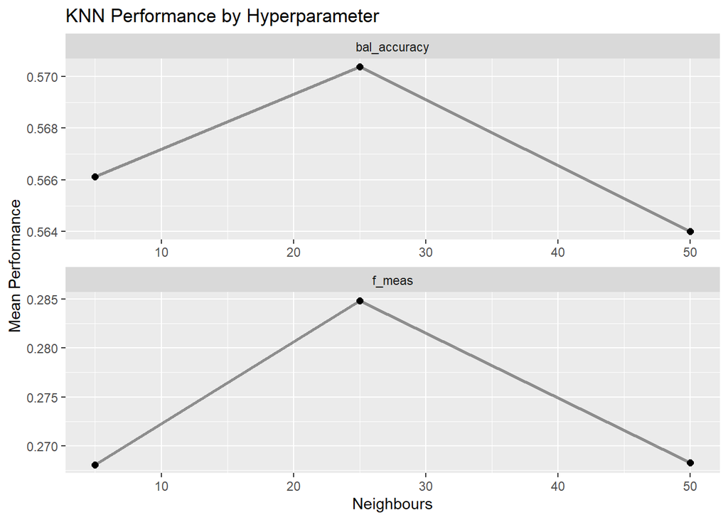

```r
# Plot performance
knn_tm_results %>% collect_metrics() %>%
  ggplot(aes(x=neighbors,y=mean)) +
  geom_line(linewidth = 1, alpha = 0.4) +
  geom_point(size = 2) +
  facet_wrap(~ .metric, scales = "free", nrow = 2) +
  scale_color_viridis_d(option = "plasma", begin = .9, end = 0) +
  labs(x = "Neighbours", y = "Mean Performance",
       title = "KNN Performance by Hyperparameter")
```

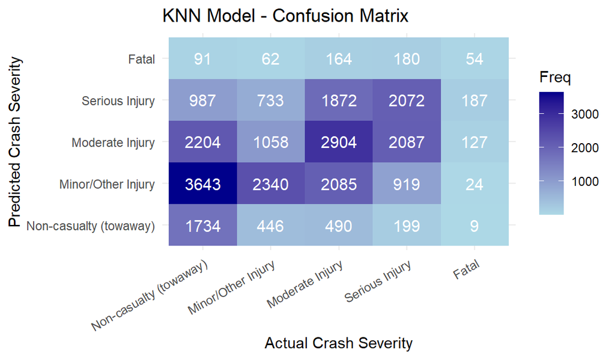

```r
# Fit best model
best_params <- select_best(knn_tm_results, metric = "bal_accuracy")
final_workflow <- finalize_workflow(knn_wf, best_params)
final_fit <- fit(final_workflow, data = knn.train)

# Test predictions and evaluation
test_predictions <- predict(final_fit, new_data = knn.test) %>%
  bind_cols(knn.test %>% dplyr::select(`Degree of crash - detailed`))
cm.knn <- confusionMatrix(test_predictions$.pred_class, test_predictions$`Degree of crash - detailed`)

conf_matrix_df <- as.data.frame(cm.knn$table)

knn_confusion <- ggplot(conf_matrix_df, aes(x = Reference, y = Prediction, fill = Freq)) +
  geom_tile() +
  geom_text(aes(label = Freq), color = "white", size = 4) +
  scale_fill_gradient(low = "lightblue", high = "darkblue") +
  labs(title = "KNN Model - Confusion Matrix",
       x = "Actual Crash Severity",
       y = "Predicted Crash Severity") +
  theme_minimal() +
  theme(axis.text.x = element_text(angle = 30, hjust = 1))

print(knn_confusion)
```

```r
rel.cm <- cm.knn
f1 <- rel.cm$byClass[,"F1"] %>% mean(na.rm=TRUE)
bal_acc <- rel.cm$byClass[,"Balanced Accuracy"] %>% mean(na.rm=TRUE)
cat("F1 score:",f1, "\n","Balanced accuracy:",bal_acc)
```

```
## F1 score: 0.2977529
##  Balanced accuracy: 0.575624
```

```r
results_df$KNN <- c("K: 25", round(f1,3), round(bal_acc, 3))
```

Given the large number of categorical features in our model, dummy coding inflates the number of variables substantially. As such, the diminished performance is expected: KNN struggles to create accurate clusters in high-dimensional spaces. Our next model, random forest, is quite different, able to naturally handle categorical variables without separate encoding.